# LTER Single-Sheet Long-Format Data Processing Trial

Jaxine Wolfe

6/19/2019

This project uses an R Markdown file (LTER_Format.Rmd) to load a single-sheet, long-format XLSX dataset containing prey count and size data for each fish dissected from the 201802 trawl survey. The data entered from this sheet have been validated in Microsoft Excel using a prey type lookup table adjacent to the raw data sheet. The output of this project generates plots of relative prey abundance and mean prey size for each fish and cruise.

## Setup

The trial diet data loaded was subset from the NOAA Fisheries 201802 cruise. The data was entered in single-sheet long-format entry with data validation of each prey item and contains both prey counts and size. Up to 10 individuals measured in each gut, indicated by the PreyNumber column, and the totals of each prey type per gut are included in the PreyCount column.

```r
# clear workspace for local development
rm(list = ls())
# set working directory
setwd("/Users/jaxinewolfe/Documents/Research/PEP/NESLTER/Data/LlopizLab/LTERformat")

# Load trial stomach content data from excel sheet
sca <- read_excel(path = "LTER_SCA_trialdata.xlsx", sheet = 1, na = "NA")
# Clean the preytype column
sca$PreySpecies <- trimws(gsub('([[:upper:]])', ' \\1', sca$PreySpecies))
str(sca)
```

```
## Classes 'tbl_df', 'tbl' and 'data.frame':    214 obs. of  12 variables:
##  $ Cruise     : num  201802 201802 201802 201802 201802 ...
##  $ Station    : num  150 150 150 150 150 150 150 150 150 150 ...
##  $ FishSpecies: chr  "A. aestivalis" "A. aestivalis" "A. aestivalis" "A. aestivalis" ...
##  $ FishNumber : num  2 2 2 2 2 2 2 2 2 2 ...
##  $ PreySpecies: chr  "Caligidae" "Caligidae" "Caligidae" "Caligidae" ...
##  $ PreyNumber : num  1 2 3 4 5 6 7 8 9 10 ...
##  $ OcularUnits: logi  NA NA NA NA NA NA ...
##  $ Mag        : logi  NA NA NA NA NA NA ...
##  $ Length_mm  : num  0.8 2.2 3.8 1.3 0.9 1.2 1.6 1.2 3.6 4.1 ...
##  $ Scope      : chr  "MZ12" "MZ12" "MZ12" "MZ12" ...
##  $ PreyCount  : num  NA NA NA NA NA NA NA NA NA NA ...
##  $ Comments   : logi  NA NA NA NA NA NA ...
```

```r
## Link to ITIS-validated taxon bins
# Merge taxa bins from resolved preytypes
# valid_path <- "/Users/jaxinewolfe/Documents/Research/PEP/NESLTER/Data/LlopizLab/Abundance/itis_validation"
# # load resolved data
# resolved_data <- read_csv(file.path(valid_path,"Llopiz_resolved.csv"))
#
# # merge data with ITIS resolved names and specified categorizations
# diet_all <- left_join(x = sca, y = resolved_data,
#                           by=(c("PreySpecies"="Llopiz_preytypes")))
```

## Relative Prey Abundance

This chunk loops through each cruise and performs an iterative analysis of relative prey abundance for each fish species. Figures are sequentially output within the working directory.

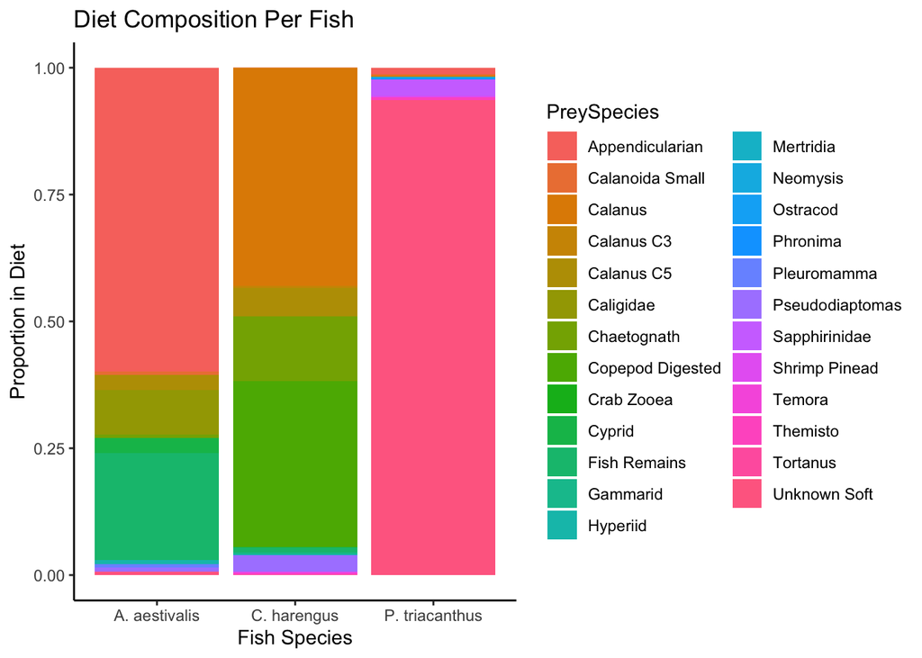

```r
# isolate unique cruises to be looped over
cruises <- unique(sca$Cruise)

# loop through cruises
for(i in 1:length(cruises)) {
  sca_percent <- sca %>%
    filter(PreyCount != "NA" & Cruise == cruises[i]) %>%
    group_by(FishSpecies) %>%
    mutate(PreyProp = PreyCount/sum(PreyCount))
  # plot relative abundance for each fish within each cruise
  p <- ggplot(data = sca_percent,
         aes(FishSpecies, PreyProp, fill = PreySpecies)) +
    geom_col() +
    # scale_fill_brewer(palette = "Set3", na.value = "grey50") +
    labs(title = "Diet Composition Per Fish", x = "Fish Species", y = "Proportion in Diet") +
    theme_classic()
  # save plot to working directory
  ggsave(paste0("RelAbund_", cruises[i], ".jpg"))
}
p
```

### Mean Prey Size

This chunk performs an iterative analysis of mean prey length in the diets of each fish species. Figures are sequentially output within the working directory.

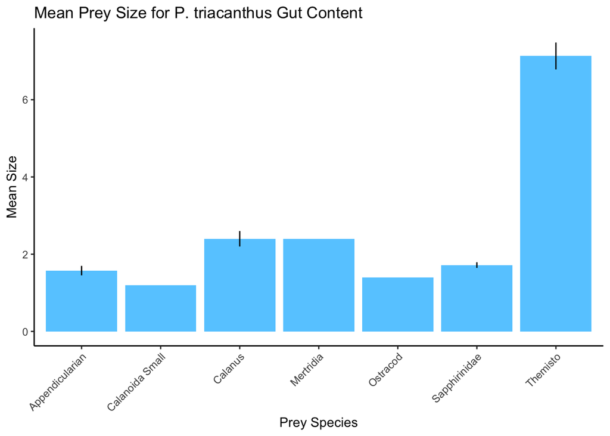

```r
fish <- unique(sca$FishSpecies)

# summarize mean prey length with standard error
sca_size <- sca %>%
  filter(PreyNumber != "NA") %>%
  group_by(FishSpecies, PreySpecies) %>%
  summarise(MeanSize = mean(Length_mm),
            ymin = (mean(Length_mm) - sd(Length_mm)/sqrt(sum(!is.na(Length_mm)))),
            ymax = (mean(Length_mm) + sd(Length_mm)/sqrt(sum(!is.na(Length_mm)))))

# loop through all fish
for(i in 1:length(fish)) {
  # plot mean prey size for each fish within each cruise
  p <- ggplot(sca_size %>% filter(FishSpecies == fish[i]),
         aes(x = PreySpecies, y = MeanSize)) +
    geom_col(position = position_dodge(), fill = "#66CCFF") +
    geom_errorbar(aes(ymin = ymin, ymax = ymax),
                  data = sca_size %>% filter(FishSpecies == fish[i]),
                  show.legend = FALSE, width = 0) +
    # geom_text_repel(aes(label=Season), size = 4) +
    theme_classic() +
    theme(axis.text.x = element_text(angle = 45, hjust = 1)) +
    labs(title = paste0("Mean Prey Size for ", fish[i], " Gut Content"),
         x = "Prey Species", y = "Mean Size")

  ggsave(paste0("MeanPreySize_", fish[i], ".jpg"))
}
p
```